# Pre Processing

```python
# Step 1: Set up the environment and import necessary libraries
import pandas as pd
import numpy as np
import torch
from sklearn.preprocessing import StandardScaler, LabelEncoder
from sklearn.model_selection import train_test_split
from imblearn.over_sampling import ADASYN
```

```python
# Load the dataset
df = pd.read_csv('C:\\Users\\chris\\OneDrive\\Desktop\\Github\\KAN\\DataCoSupplyChainDataset.csv', header=0, encoding='unicode_escape')
```

```python
df.shape
```

```
(180519, 53)
```

```python
df.info()
```

```
<class 'pandas.core.frame.DataFrame'>
RangeIndex: 180519 entries, 0 to 180518
Data columns (total 53 columns):
 #   Column                         Non-Null Count   Dtype
---  ------                         --------------   -----
 0   Type                           180519 non-null  object
 1   Days for shipping (real)       180519 non-null  int64
 2   Days for shipment (scheduled)  180519 non-null  int64
 3   Benefit per order              180519 non-null  float64
 4   Sales per customer             180519 non-null  float64
 5   Delivery Status                180519 non-null  object
 6   Late_delivery_risk             180519 non-null  int64
 7   Category Id                    180519 non-null  int64
 8   Category Name                  180519 non-null  object
 9   Customer City                  180519 non-null  object
```

[output cut: 45 more lines]

```python
df.isnull().sum()
```

```
Type                                  0
Days for shipping (real)              0
Days for shipment (scheduled)         0
Benefit per order                     0
Sales per customer                    0
Delivery Status                       0
Late_delivery_risk                    0
Category Id                           0
Category Name                         0
Customer City                         0
Customer Country                      0
Customer Email                        0
Customer Fname                        0
Customer Id                           0
Customer Lname                        8
Customer Password                     0
Customer Segment                      0
Customer State                        0
Customer Street                       0
Customer Zipcode                      3
Department Id                         0
Department Name                       0
Latitude                              0
Longitude                             0
Market                                0
Order City                            0
Order Country                         0
Order Customer Id                     0
order date (DateOrders)               0
Order Id                              0
Order Item Cardprod Id                0
Order Item Discount                   0
Order Item Discount Rate              0
Order Item Id                         0
Order Item Product Price              0
Order Item Profit Ratio               0
Order Item Quantity                   0
Sales                                 0
Order Item Total                      0
Order Profit Per Order                0
Order Region                          0
Order State                           0
Order Status                          0
Order Zipcode                    155679
Product Card Id                       0
Product Category Id                   0
Product Description              180519
Product Image                         0
Product Name                          0
Product Price                         0
Product Status                        0
shipping date (DateOrders)            0
Shipping Mode                         0
dtype: int64
```

```python
# Combine first and last names into a full name column
df['Cust_Full_Name'] = df['Customer Fname'].astype(str) + df['Customer Lname'].astype(str)
```

```python
df.select_dtypes(include=['object']).describe()
```

|  | Type | Delivery Status | Category Name | Customer City | Customer Country | Customer Email | Customer Fname | Customer Lname | Customer Password | Customer Segment | ... | Order Country | order date (DateOrders) | Order Region | Order State | Order Status | Product Image | Product Name | shipping date (DateOrders) | Shipping Mode | Cust_Full_Name |
| --- | --- | --- | --- | --- | --- | --- | --- | --- | --- | --- | --- | --- | --- | --- | --- | --- | --- | --- | --- | --- | --- |
| count | 180519 | 180519 | 180519 | 180519 | 180519 | 180519 | 180519 | 180511 | 180519 | 180519 | ... | 180519 | 180519 | 180519 | 180519 | 180519 | 180519 | 180519 | 180519 | 180519 | 180519 |
| unique | 4 | 4 | 50 | 563 | 2 | 1 | 782 | 1109 | 1 | 3 | ... | 164 | 65752 | 23 | 1089 | 9 | 118 | 118 | 63701 | 4 | 14033 |
| top | DEBIT | Late delivery | Cleats | Caguas | EE. UU. | XXXXXXXXX | Mary | Smith | XXXXXXXXX | Consumer | ... | Estados Unidos | 12/14/2016 12:29 | Central America | Inglaterra | COMPLETE | http://images.acmesports.sports/Perfect+Fitnes... | Perfect Fitness Perfect Rip Deck | 1/5/2016 5:58 | Standard Class | MarySmith |
| freq | 69295 | 98977 | 24551 | 66770 | 111146 | 180519 | 65150 | 64104 | 180519 | 93504 | ... | 24840 | 5 | 28341 | 6722 | 59491 | 24515 | 24515 | 10 | 107752 | 23884 |

4 rows × 25 columns

# Data Cleaning

```python
# Drop unnecessary columns
data = df.drop(['Customer Email', 'Product Status', 'Customer Password', 'Customer Street', 'Customer Fname',
                'Customer Lname', 'Latitude', 'Longitude', 'Product Description', 'Product Image', 'Order Zipcode',
                'shipping date (DateOrders)'], axis=1)
```

```python
# Drop rows with missing values in 'Product Price' and 'Shipping Mode'
data = data.dropna(subset=['Product Price', 'Shipping Mode'])
```

```python
# Split order dates into year, month, day, and hour
data['order_yr'] = pd.DatetimeIndex(data['order date (DateOrders)']).year
data['order_month'] = pd.DatetimeIndex(data['order date (DateOrders)']).month
data['order_day'] = pd.DatetimeIndex(data['order date (DateOrders)']).weekday
data['order_hour'] = pd.DatetimeIndex(data['order date (DateOrders)']).hour
```

# Visulizations

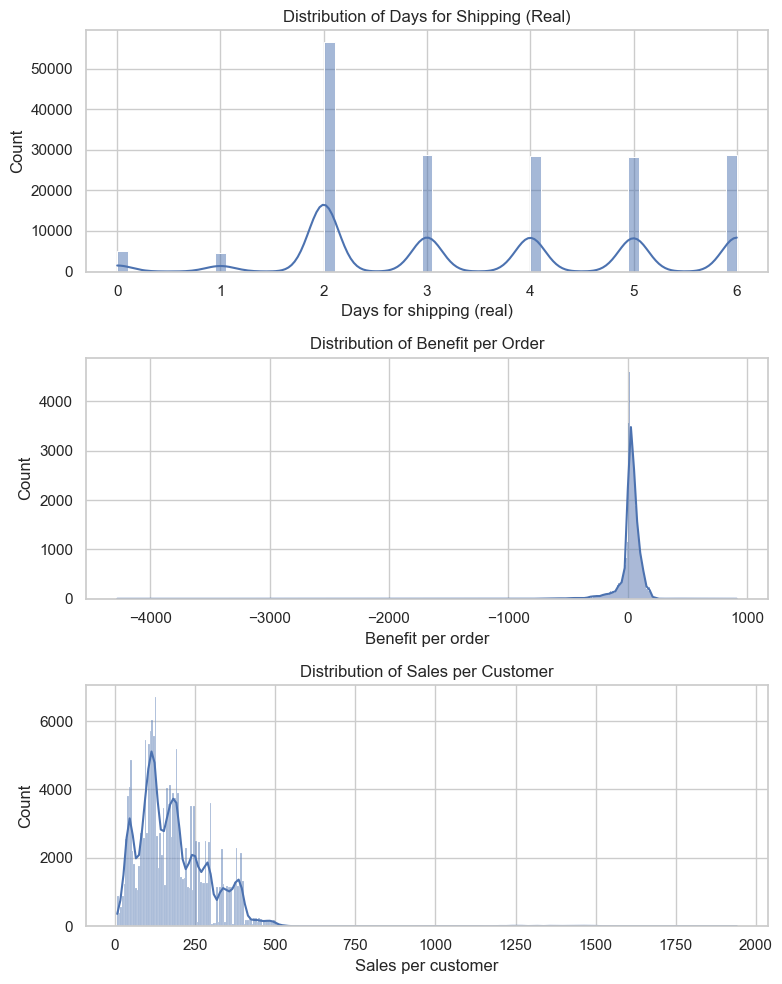

```python
import matplotlib.pyplot as plt
import seaborn as sns

# Setting up the visual style for the plots
sns.set(style="whitegrid")

# Step 1: Distribution of Key Numerical Variables
fig, axs = plt.subplots(3, 1, figsize=(8, 10))

# Histogram of Days for shipping (real)
sns.histplot(data, x='Days for shipping (real)', kde=True, ax=axs[0])
axs[0].set_title('Distribution of Days for Shipping (Real)')

# Histogram of Benefit per order
sns.histplot(data, x='Benefit per order', kde=True, ax=axs[1])
axs[1].set_title('Distribution of Benefit per Order')

# Histogram of Sales per Customer
sns.histplot(data, x='Sales per customer', kde=True, ax=axs[2])
axs[2].set_title('Distribution of Sales per Customer')

# Step 2: Categorical Data Analysis (in subsequent cells due to plot size considerations)
plt.tight_layout()
plt.show()
```

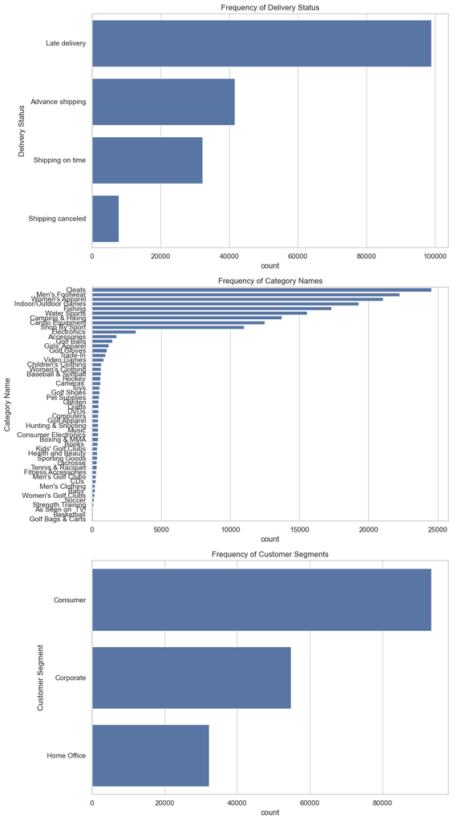

```python
#  Categorical Data Analysis
fig, axs = plt.subplots(3, 1, figsize=(10, 18))

# Bar plot of Delivery Status
sns.countplot(data, y='Delivery Status', order=data['Delivery Status'].value_counts().index, ax=axs[0])
axs[0].set_title('Frequency of Delivery Status')

# Bar plot of Category Name
sns.countplot(data, y='Category Name',  order=data['Category Name'].value_counts().index, ax=axs[1])
axs[1].set_title('Frequency of Category Names')

# Bar plot of Customer Segment
sns.countplot(data, y='Customer Segment',  order=data['Customer Segment'].value_counts().index, ax=axs[2])
axs[2].set_title('Frequency of Customer Segments')

plt.tight_layout()
plt.show()
```

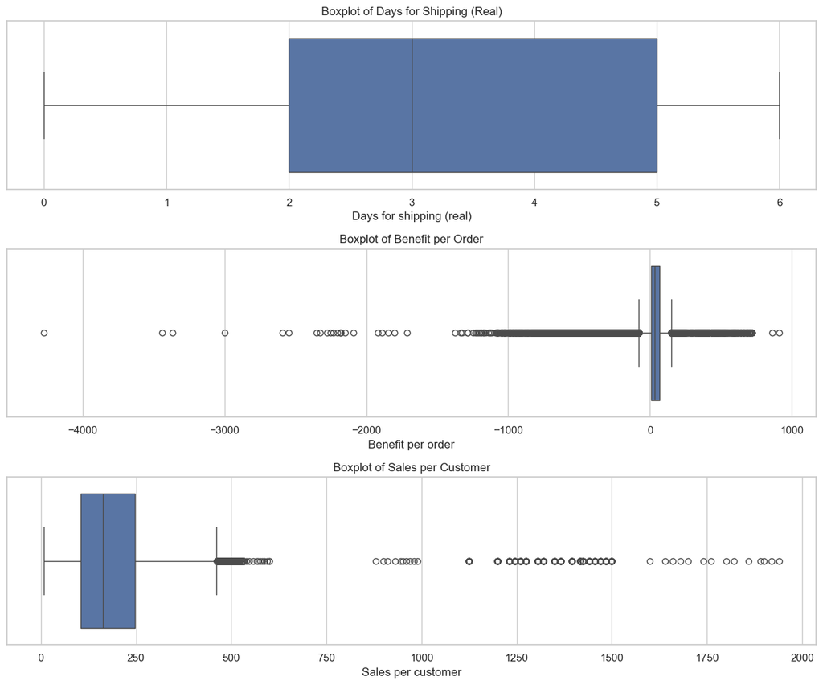

```python
#  Outliers Detection
fig, axs = plt.subplots(3, 1, figsize=(12, 10))

# Boxplot for Days for shipping (real)
sns.boxplot(data, x='Days for shipping (real)', ax=axs[0])
axs[0].set_title('Boxplot of Days for Shipping (Real)')

# Boxplot for Benefit per order
sns.boxplot(data, x='Benefit per order', ax=axs[1])
axs[1].set_title('Boxplot of Benefit per Order')

# Boxplot for Sales per customer
sns.boxplot(data, x='Sales per customer', ax=axs[2])
axs[2].set_title('Boxplot of Sales per Customer')

plt.tight_layout()
plt.show()
```

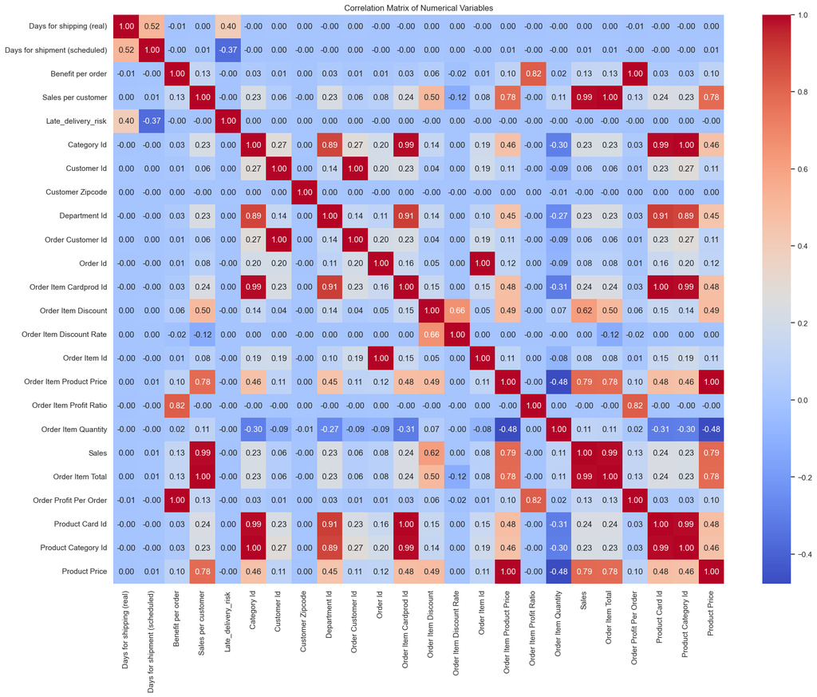

```python
# Correlation Matrix
correlation_matrix = data.select_dtypes(include=['float64', 'int64']).corr()

plt.figure(figsize=(20, 15))
sns.heatmap(correlation_matrix, annot=True, fmt=".2f", cmap="coolwarm")
plt.title('Correlation Matrix of Numerical Variables')
plt.show()
```

```python
# We will create a baseline for loss if the Benifit per order is less than 0

loss = data[data['Benefit per order']<0]
loss['Category Name'].value_counts().nlargest(10)
```

```
Category Name
Cleats                  4590
Men's Footwear          4169
Women's Apparel         3923
Indoor/Outdoor Games    3617
Fishing                 3209
Water Sports            2924
Camping & Hiking        2590
Cardio Equipment        2332
Shop By Sport           2154
Electronics              562
Name: count, dtype: int64
```

```python
loss['Market'].value_counts().nlargest(10)
```

```
Market
LATAM           9588
Europe          9420
Pacific Asia    7806
USCA            4812
Africa          2158
Name: count, dtype: int64
```

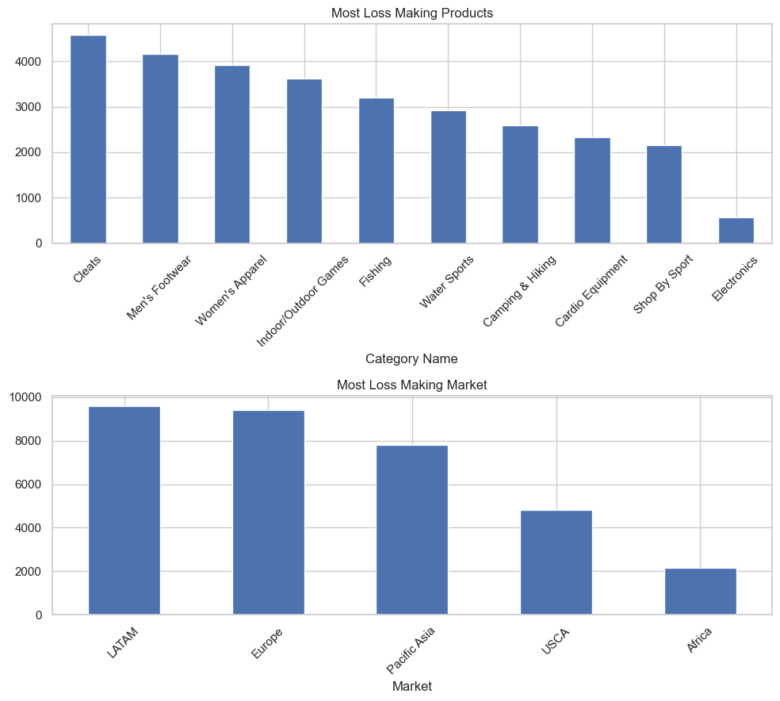

```python
# Setting up the figure with two subplots
fig, axs = plt.subplots(2, 1, figsize=(10, 9))  # Adjusting the size for better visibility

# Plotting the Most Loss Making Products
loss['Category Name'].value_counts().nlargest(10).plot.bar(ax=axs[0])
axs[0].set_title("Most Loss Making Products")
axs[0].set_xticklabels(axs[0].get_xticklabels(), rotation=45)


# Plotting the Most Loss Making Markets
loss['Market'].value_counts().nlargest(10).plot.bar(ax=axs[1])
axs[1].set_title("Most Loss Making Market")
axs[1].set_xticklabels(axs[1].get_xticklabels(), rotation=45)

plt.tight_layout()
plt.show()
```

```python
# Grouping order status by payment type

status = data.groupby('Type')['Order Status'].value_counts()

status_df = pd.DataFrame(status)

status_df
```

| Type | Order Status | count |
| --- | --- | --- |
| CASH | CLOSED | 19616 |
| DEBIT | COMPLETE | 59491 |
|  | ON_HOLD | 9804 |
| PAYMENT | PENDING_PAYMENT | 39832 |
|  | PAYMENT_REVIEW | 1893 |
| TRANSFER | PROCESSING | 21902 |
|  | PENDING | 20227 |
|  | SUSPECTED_FRAUD | 4062 |
|  | CANCELED | 3692 |

```python
# Now using the suspected fraud to know the products with most fraud cases

fraud_region = data[data['Order Status'] == 'SUSPECTED_FRAUD']
```

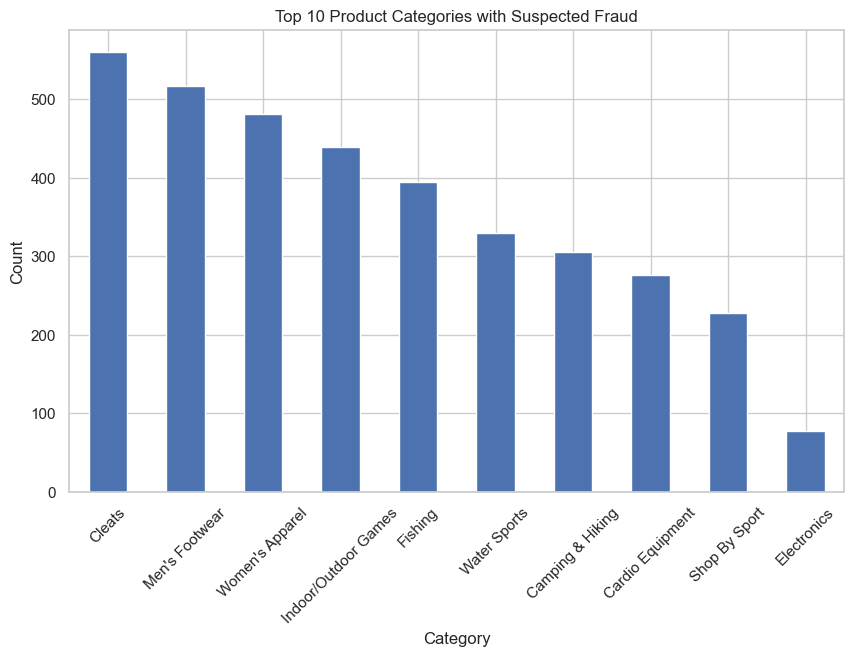

```python
# Getting the counts of the top 10 categories
temp = fraud_region['Category Name'].value_counts().nlargest(10)

plt.figure(figsize=(10, 6))  # Setting the figure size

# Creating the bar plot
temp.plot(kind='bar')

# Adding titles and labels
plt.title('Top 10 Product Categories with Suspected Fraud')
plt.xlabel('Category')
plt.ylabel('Count')
plt.xticks(rotation=45)  # Rotating the x-ticks for better readability

# Displaying the plot
plt.show()
```

# Prepping Data for Model

since our dataset is so huge and it takes a lot of compute I reducing the dataset to a smaller size this is due to the lack of compute but I tried to capture maximum amount of information in this smaller dataset

```python
data = data.sample(n=500, random_state=45)
```

```python
# Create a 'flagged' column for suspected fraud

data['flagged'] = np.where(
    (data['Order Status'] == 'SUSPECTED_FRAUD') |
    ((data['Order Status'] == 'SUSPECTED_FRAUD') & (data['Delivery Status'] == 'Late delivery')), 1, 0
)




# Drop rows with missing values in 'Customer Zipcode'
data = data.dropna(subset=['Customer Zipcode'])
```

```python
data.head(5)
```

|  | Type | Days for shipping (real) | Days for shipment (scheduled) | Benefit per order | Sales per customer | Delivery Status | Late_delivery_risk | Category Id | Category Name | Customer City | ... | Product Category Id | Product Name | Product Price | Shipping Mode | Cust_Full_Name | order_yr | order_month | order_day | order_hour | flagged |
| --- | --- | --- | --- | --- | --- | --- | --- | --- | --- | --- | --- | --- | --- | --- | --- | --- | --- | --- | --- | --- | --- |
| 24058 | CASH | 6 | 4 | 24.290001 | 80.970001 | Late delivery | 1 | 44 | Hunting & Shooting | Buffalo | ... | 44 | ENO Atlas Hammock Straps | 29.990000 | Standard Class | MaryMoss | 2015 | 1 | 4 | 18 | 0 |
| 112001 | DEBIT | 2 | 2 | 19.540001 | 84.970001 | Shipping on time | 0 | 46 | Indoor/Outdoor Games | Caguas | ... | 46 | O'Brien Men's Neoprene Life Vest | 49.980000 | Second Class | JonathanWilson | 2016 | 11 | 0 | 2 | 0 |
| 10807 | TRANSFER | 2 | 1 | 2.630000 | 21.000000 | Late delivery | 1 | 26 | Girls' Apparel | Caguas | ... | 26 | adidas Men's Germany Black Crest Away Tee | 25.000000 | First Class | DebraSnow | 2015 | 4 | 4 | 21 | 0 |
| 112851 | PAYMENT | 2 | 1 | -20.990000 | 167.929993 | Late delivery | 1 | 46 | Indoor/Outdoor Games | Washington | ... | 46 | O'Brien Men's Neoprene Life Vest | 49.980000 | First Class | MarySmith | 2016 | 10 | 5 | 20 | 0 |
| 140846 | CASH | 6 | 4 | 79.370003 | 283.480011 | Late delivery | 1 | 43 | Camping & Hiking | Caguas | ... | 43 | Diamondback Women's Serene Classic Comfort Bi | 299.980011 | Standard Class | BobbyCrawford | 2016 | 8 | 2 | 2 | 0 |

5 rows × 47 columns

```python
data.tail(5)
```

|  | Type | Days for shipping (real) | Days for shipment (scheduled) | Benefit per order | Sales per customer | Delivery Status | Late_delivery_risk | Category Id | Category Name | Customer City | ... | Product Category Id | Product Name | Product Price | Shipping Mode | Cust_Full_Name | order_yr | order_month | order_day | order_hour | flagged |
| --- | --- | --- | --- | --- | --- | --- | --- | --- | --- | --- | --- | --- | --- | --- | --- | --- | --- | --- | --- | --- | --- |
| 106855 | DEBIT | 2 | 4 | 23.750000 | 87.959999 | Advance shipping | 0 | 46 | Indoor/Outdoor Games | Caguas | ... | 46 | O'Brien Men's Neoprene Life Vest | 49.980000 | Standard Class | MarySmith | 2017 | 3 | 3 | 5 | 0 |
| 27287 | DEBIT | 3 | 4 | 47.590000 | 135.970001 | Advance shipping | 0 | 29 | Shop By Sport | Cleveland | ... | 29 | Under Armour Girls' Toddler Spine Surge Runni | 39.990002 | Standard Class | DorothyMerritt | 2016 | 3 | 5 | 4 | 0 |
| 54022 | DEBIT | 4 | 2 | 42.000000 | 149.990005 | Late delivery | 1 | 48 | Water Sports | Wyoming | ... | 48 | Pelican Sunstream 100 Kayak | 199.990005 | Second Class | AnnaSmith | 2017 | 7 | 5 | 23 | 0 |
| 56826 | DEBIT | 5 | 4 | 53.549999 | 127.500000 | Late delivery | 1 | 24 | Women's Apparel | Caguas | ... | 24 | Nike Men's Dri-FIT Victory Golf Polo | 50.000000 | Standard Class | MatthewNorman | 2015 | 10 | 4 | 1 | 0 |
| 80251 | DEBIT | 2 | 4 | -270.589996 | 163.990005 | Advance shipping | 0 | 48 | Water Sports | Caguas | ... | 48 | Pelican Sunstream 100 Kayak | 199.990005 | Standard Class | RobertSmith | 2016 | 3 | 3 | 14 | 0 |

5 rows × 47 columns

```python
data
```

|  | Type | Days for shipping (real) | Days for shipment (scheduled) | Benefit per order | Sales per customer | Delivery Status | Late_delivery_risk | Category Id | Category Name | Customer City | ... | Product Category Id | Product Name | Product Price | Shipping Mode | Cust_Full_Name | order_yr | order_month | order_day | order_hour | flagged |
| --- | --- | --- | --- | --- | --- | --- | --- | --- | --- | --- | --- | --- | --- | --- | --- | --- | --- | --- | --- | --- | --- |
| 24058 | CASH | 6 | 4 | 24.290001 | 80.970001 | Late delivery | 1 | 44 | Hunting & Shooting | Buffalo | ... | 44 | ENO Atlas Hammock Straps | 29.990000 | Standard Class | MaryMoss | 2015 | 1 | 4 | 18 | 0 |
| 112001 | DEBIT | 2 | 2 | 19.540001 | 84.970001 | Shipping on time | 0 | 46 | Indoor/Outdoor Games | Caguas | ... | 46 | O'Brien Men's Neoprene Life Vest | 49.980000 | Second Class | JonathanWilson | 2016 | 11 | 0 | 2 | 0 |
| 10807 | TRANSFER | 2 | 1 | 2.630000 | 21.000000 | Late delivery | 1 | 26 | Girls' Apparel | Caguas | ... | 26 | adidas Men's Germany Black Crest Away Tee | 25.000000 | First Class | DebraSnow | 2015 | 4 | 4 | 21 | 0 |
| 112851 | PAYMENT | 2 | 1 | -20.990000 | 167.929993 | Late delivery | 1 | 46 | Indoor/Outdoor Games | Washington | ... | 46 | O'Brien Men's Neoprene Life Vest | 49.980000 | First Class | MarySmith | 2016 | 10 | 5 | 20 | 0 |
| 140846 | CASH | 6 | 4 | 79.370003 | 283.480011 | Late delivery | 1 | 43 | Camping & Hiking | Caguas | ... | 43 | Diamondback Women's Serene Classic Comfort Bi | 299.980011 | Standard Class | BobbyCrawford | 2016 | 8 | 2 | 2 | 0 |
| ... | ... | ... | ... | ... | ... | ... | ... | ... | ... | ... | ... | ... | ... | ... | ... | ... | ... | ... | ... | ... | ... |
| 106855 | DEBIT | 2 | 4 | 23.750000 | 87.959999 | Advance shipping | 0 | 46 | Indoor/Outdoor Games | Caguas | ... | 46 | O'Brien Men's Neoprene Life Vest | 49.980000 | Standard Class | MarySmith | 2017 | 3 | 3 | 5 | 0 |
| 27287 | DEBIT | 3 | 4 | 47.590000 | 135.970001 | Advance shipping | 0 | 29 | Shop By Sport | Cleveland | ... | 29 | Under Armour Girls' Toddler Spine Surge Runni | 39.990002 | Standard Class | DorothyMerritt | 2016 | 3 | 5 | 4 | 0 |
| 54022 | DEBIT | 4 | 2 | 42.000000 | 149.990005 | Late delivery | 1 | 48 | Water Sports | Wyoming | ... | 48 | Pelican Sunstream 100 Kayak | 199.990005 | Second Class | AnnaSmith | 2017 | 7 | 5 | 23 | 0 |
| 56826 | DEBIT | 5 | 4 | 53.549999 | 127.500000 | Late delivery | 1 | 24 | Women's Apparel | Caguas | ... | 24 | Nike Men's Dri-FIT Victory Golf Polo | 50.000000 | Standard Class | MatthewNorman | 2015 | 10 | 4 | 1 | 0 |
| 80251 | DEBIT | 2 | 4 | -270.589996 | 163.990005 | Advance shipping | 0 | 48 | Water Sports | Caguas | ... | 48 | Pelican Sunstream 100 Kayak | 199.990005 | Standard Class | RobertSmith | 2016 | 3 | 3 | 14 | 0 |

500 rows × 47 columns

```python
data['flagged'].value_counts()
```

```
flagged
0    483
1     17
Name: count, dtype: int64
```

to address this imbalance lets encode the text variables then lets split the data based on the flagged variables finally we will be using standard scaler to standardize our numerical features